# DALEX_TechQualityControl

Scott Coffin

2/23/2021

# 1 Setup

## 1.2 Data Selection

**Important**: this datasethas been filtered for ‘red’ criteria for technical quality AND risk asssessment applicability quality.

Data summary

| Name | df |
| --- | --- |
| Number of rows | 2188 |
| Number of columns | 19 |
| _______________________ |  |
| Column type frequency: |  |
| factor | 11 |
| numeric | 8 |
| ________________________ |  |
| Group variables | None |

**Variable type: factor**

| skim_variable | n_missing | complete_rate | ordered | n_unique | top_counts |
| --- | --- | --- | --- | --- | --- |
| organism.group | 0 | 1 | FALSE | 10 | Cru: 795, Fis: 528, Mol: 433, Alg: 222 |
| lvl1_f | 0 | 1 | FALSE | 7 | Fit: 1522, Met: 485, Beh: 95, Str: 44 |
| life.stage | 0 | 1 | FALSE | 4 | Ear: 974, Adu: 759, Not: 253, Juv: 202 |
| bio.org | 0 | 1 | FALSE | 5 | org: 1163, sub: 668, cel: 251, tis: 59 |
| polymer | 0 | 1 | FALSE | 7 | PS: 1262, PE: 588, PET: 129, PP: 106 |
| shape | 0 | 1 | FALSE | 3 | sph: 1463, fra: 649, fib: 76, Not: 0 |
| effect.metric | 0 | 1 | FALSE | 3 | not: 1576, NOE: 318, LOE: 294, EC1: 0 |
| environment | 0 | 1 | FALSE | 3 | Mar: 1384, Fre: 770, Ter: 34 |
| exposure.route | 0 | 1 | FALSE | 3 | wat: 2145, med: 34, sed: 9, cop: 0 |
| lvl2_f | 0 | 1 | FALSE | 25 | Mor: 412, Rep: 368, Oxi: 288, Dev: 287 |
| effect_10 | 0 | 1 | FALSE | 2 | 0: 1504, 1: 684 |

**Variable type: numeric**

| skim_variable | n_missing | complete_rate | mean | sd | p0 | p25 | p50 | p75 | p100 | hist |
| --- | --- | --- | --- | --- | --- | --- | --- | --- | --- | --- |
| exposure.duration.d | 0 | 1 | 0.93 | 0.73 | -1.40 | 0.48 | 1.00 | 1.32 | 1.98 | ▁▁▆▆▇ |
| dose.um3.mL.master | 0 | 1 | 5.84 | 2.34 | -5.67 | 4.42 | 6.02 | 7.37 | 14.32 | ▁▁▇▆▁ |
| dose.mg.L.master | 0 | 1 | -0.23 | 2.20 | -11.64 | -1.70 | -0.30 | 1.40 | 8.17 | ▁▁▇▆▁ |
| dose.particles.mL.master | 0 | 1 | 4.24 | 4.05 | -4.20 | 1.05 | 3.40 | 7.20 | 21.36 | ▃▇▃▁▁ |
| size.length.um.used.for.conversions | 0 | 1 | 0.71 | 1.32 | -4.00 | -0.30 | 0.78 | 1.45 | 3.70 | ▁▃▅▇▃ |
| treatments | 0 | 1 | 0.58 | 0.15 | 0.00 | 0.48 | 0.60 | 0.60 | 1.00 | ▁▁▆▇▁ |
| particle.volume.um3 | 0 | 1 | 1.60 | 3.76 | -12.28 | -1.18 | 2.05 | 3.73 | 10.21 | ▁▃▆▇▃ |
| density.mg.um.3 | 0 | 1 | -8.98 | 0.04 | -9.06 | -9.00 | -8.97 | -8.97 | -8.85 | ▃▂▇▁▁ |

# 2 Modelling

## 2.1 Model Performance

### 2.1.1 Histogram of Residuals

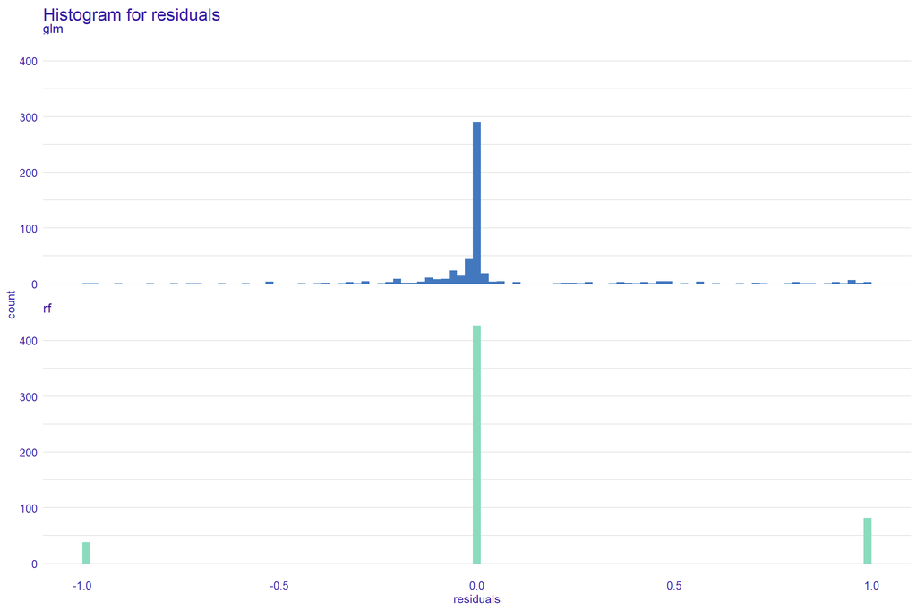

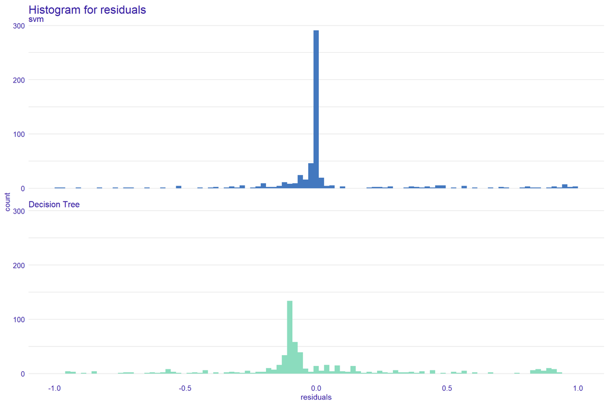

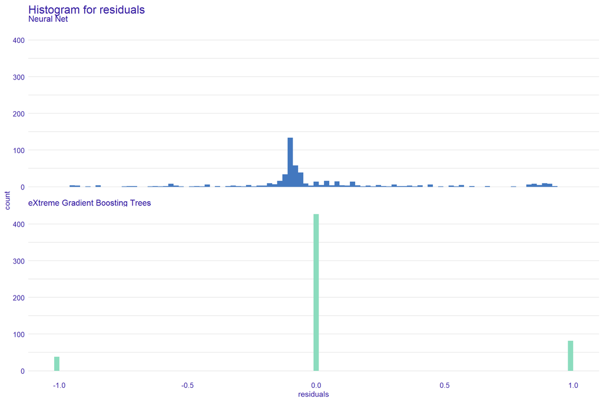

### Precision Recall Curves

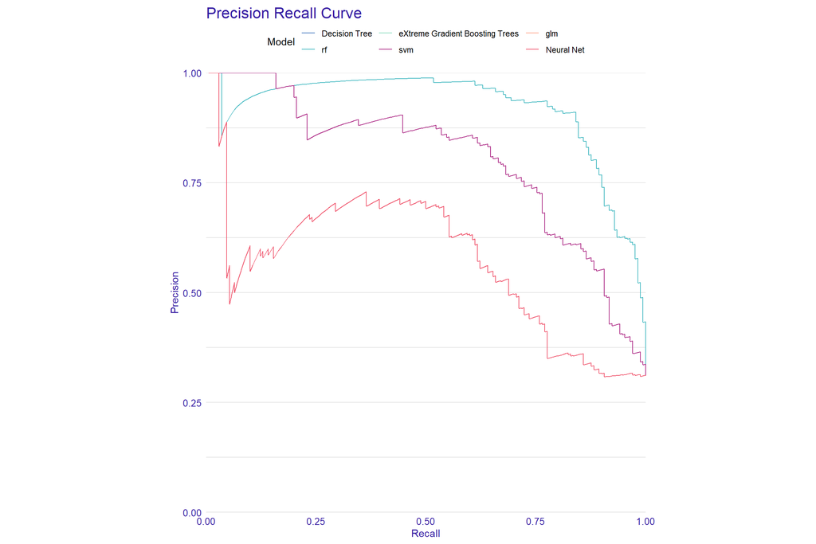

### 2.1.2 Reverse Cumulative Distribution of Residuals

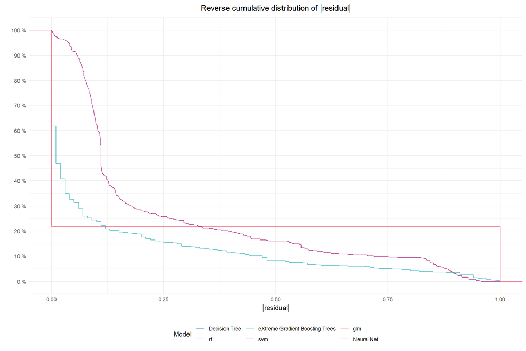

#### Residuals

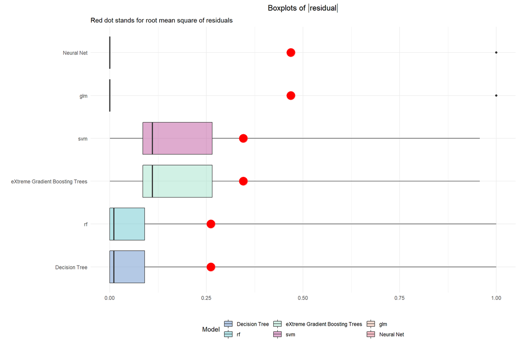

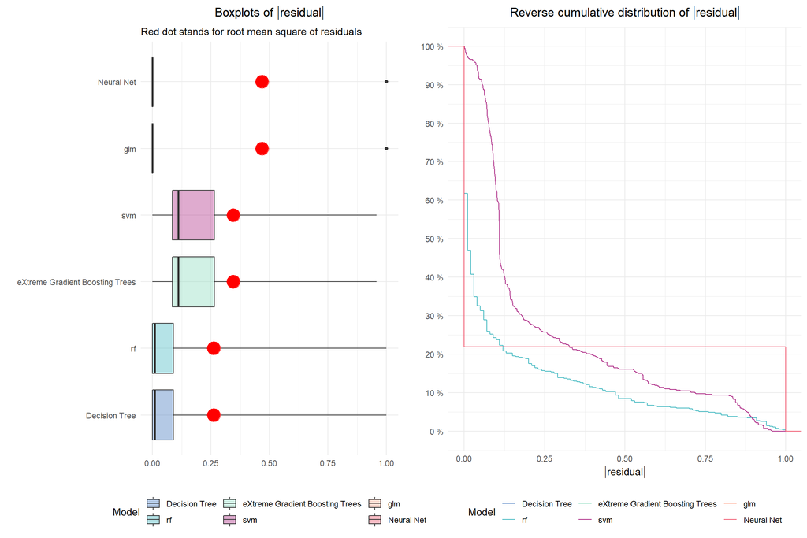

### 2.1.3 Lift Curves

Lift curves describe a performance coefficient (lift) over the cumulative proportion of a population. Lift is calculated as the ratio of “yes’s” on a certain sample point (for toxicity) divided by the ratio of “yes’s” on the whole dataset. $Lift = Predicted Rate/Average Rate$.

##### 2.1.3.0.1 ALT METHOD

http://rstudio-pubs-static.s3.amazonaws.com/436131_3212dcf341cc422590f1a9f52830cfd6.html

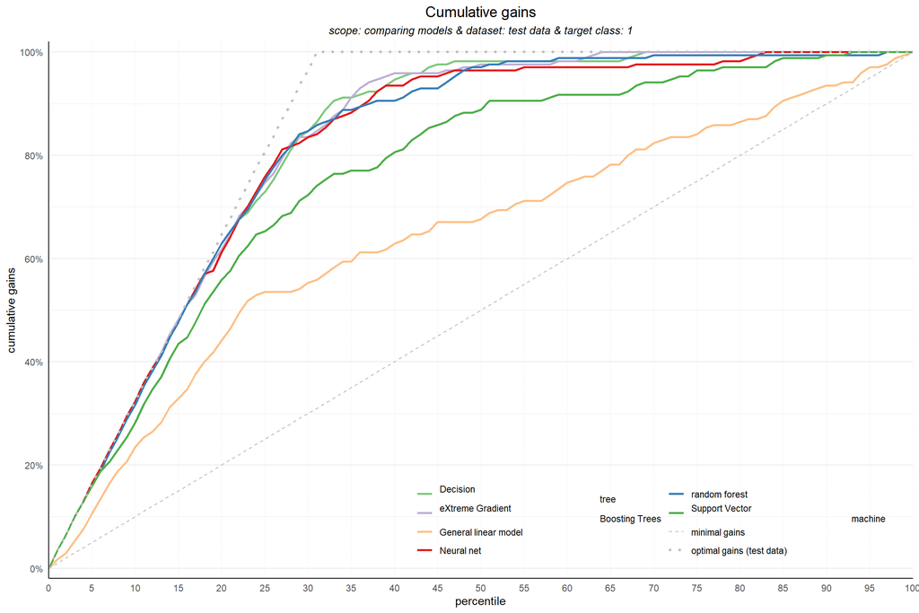

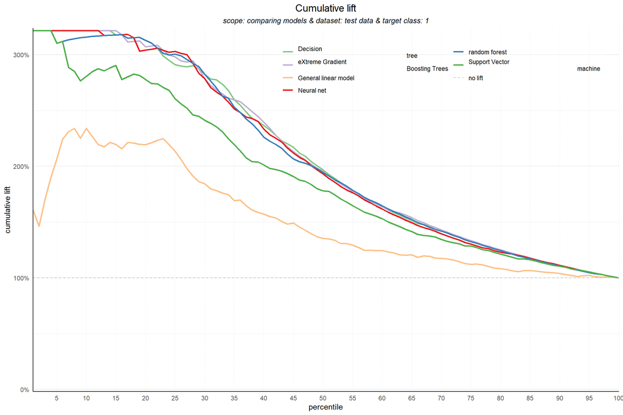

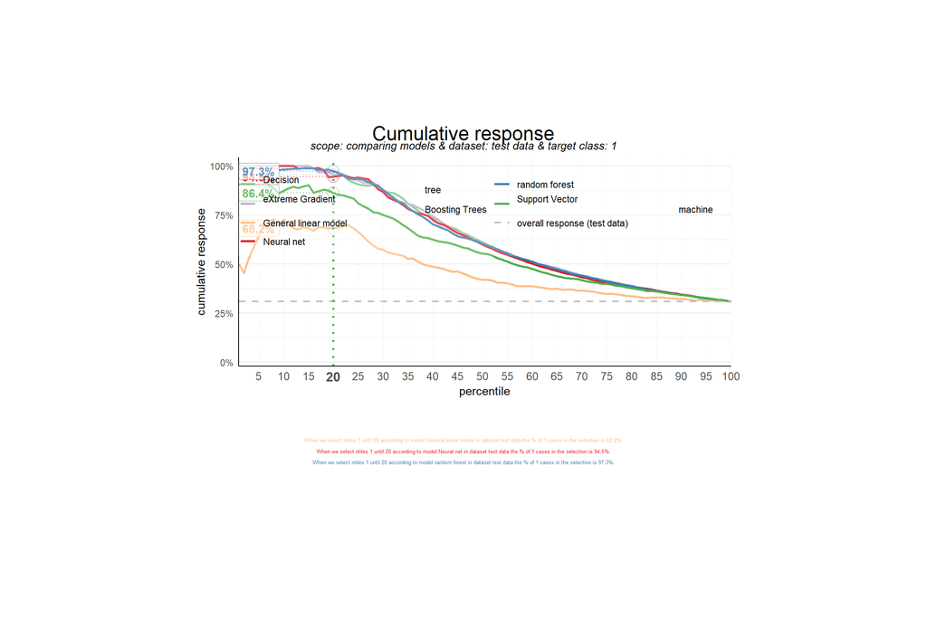

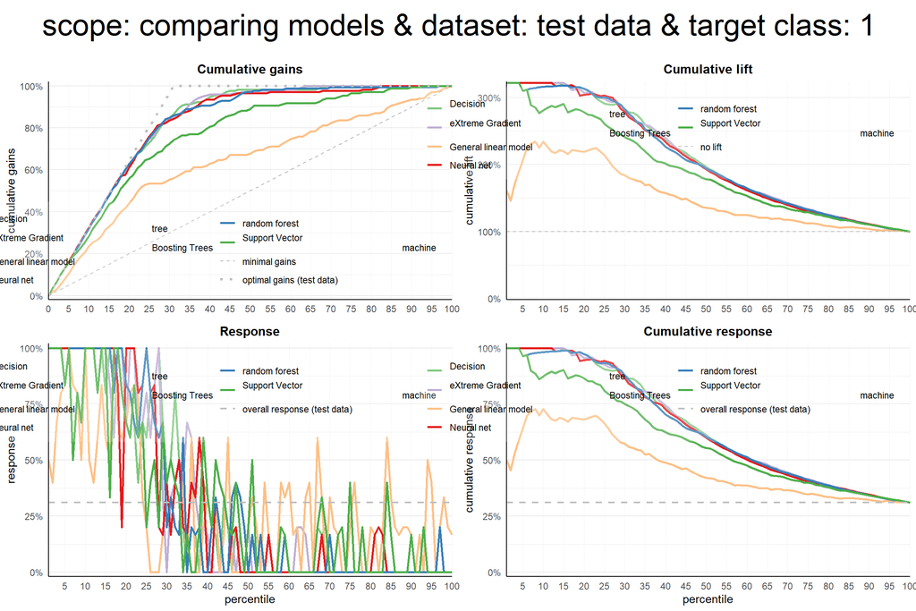

### 2.1.4 Roc Curves

[figure not shown]

### 2.1.5 Variable Importance

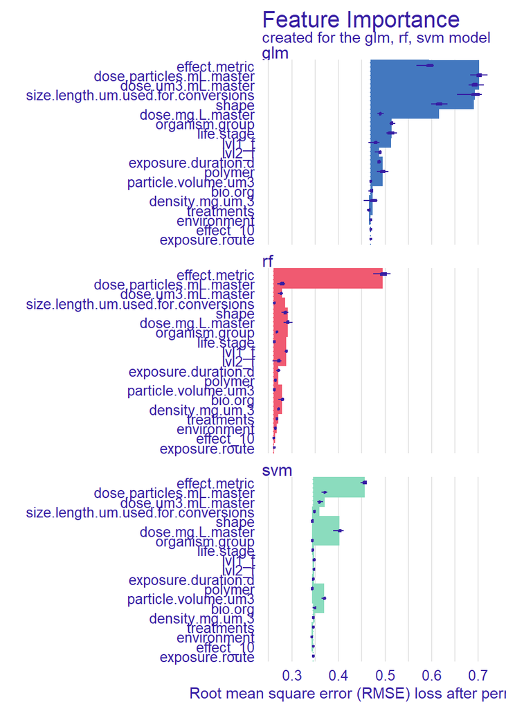

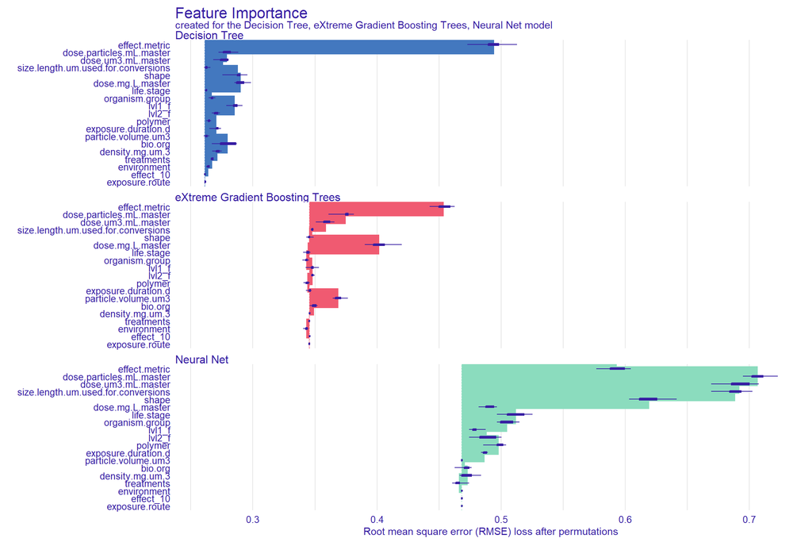

### 2.1.6 Partial Dependence Plot

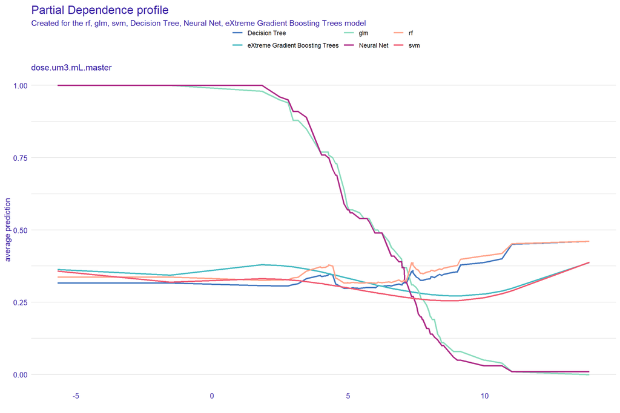

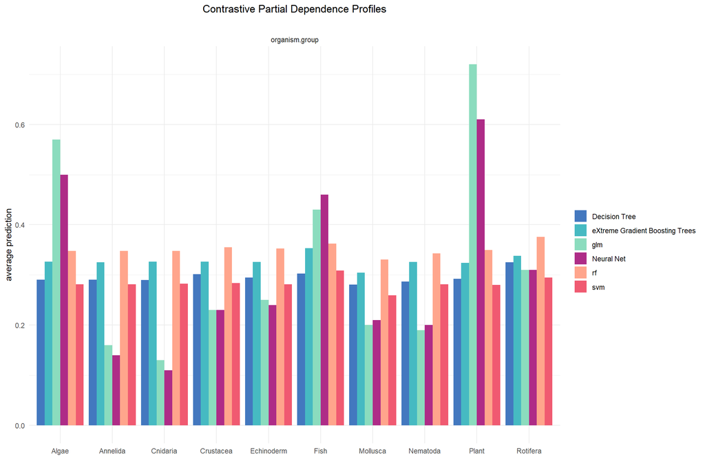